# Heart rate variability across 24 hours in healthy young adults

An independent re-analysis of the public MMASH dataset

Published

October 21, 2026

**Note**

This is an **independent analysis of a public dataset**. I did not collect these data. All analyses are **exploratory and non-causal**.

# Question

How does heart rate variability (HRV) change over 24 hours of everyday life, how different is it during sleep and wakefulness, and does it relate to chronotype or to momentary affect? The analysis follows a standard time-domain HRV pipeline (Laborde et al. 2017; Shaffer and Ginsberg 2017). The 24-h profile is modelled with a generalised additive mixed model (GAMM) and a chronotype interaction, the model family that Balter et al. (2024) used for diurnal variation in self-reported psychiatric symptoms (they did not study HRV).

# Data

MMASH v1.0.0 (Rossi et al. 2020a, 2020b) contains 24 h of beat-to-beat intervals from a Polar H7 chest strap, actigraphy-estimated sleep, and questionnaires for 22 healthy young adult men. The questionnaires cover chronotype (MEQ) and positive and negative affect (PANAS) at five time points. The raw data are not redistributed here.

# Methods

**1. Artefact handling (Python).** Inter-beat intervals (IBIs) outside 0.3–2.0 s (200–30 bpm) were removed. Each remaining beat was compared with the median of the 11 surrounding in-range beats and removed if it deviated by more than 20 % (a local-median variant of the Malik 20 % successive-difference rule). Successive differences were used only between two valid beats that were adjacent in the original series, with no recording gap > 3 s in between.

**2. 5-min windows.** In clock-aligned 5-min windows I computed mean HR, SDNN, RMSSD and lnRMSSD. A window was *usable* if valid IBIs covered ≥ 60 % of it (≥ 180 s), ≤ 20 % of its beats were removed, and it had ≥ 100 valid successive differences. The 60 % threshold reflects a property of the data: in every recording, about 8 s of beats are missing roughly every 33 s, so no window exceeds ~78 % coverage.

**3. Sleep vs wake.** Windows lying entirely between actigraphy sleep onset and getting up were labelled *sleep*. Windows lying entirely outside the night (first bedtime to last get-up) were labelled *wake*. Windows that overlapped the night but were not fully asleep were excluded. For each participant I took the median of each metric by state and compared the two states with paired Wilcoxon signed-rank tests.

**4. 24-h profile (R, mgcv).** lnRMSSD and mean HR were modelled with `bam()`. Each model has a cyclic cubic smooth of clock time (k = 16), a random intercept per participant, and an AR(1) error for consecutive windows (ρ = 0.78). A sensitivity model replaced the random intercept with participant-specific cyclic smooths (factor-smooth interaction). The exploratory chronotype model added `s(MEQ)` and a `ti(clock, MEQ)` interaction, alongside participant-specific smooths.

**5. HRV and affect.** For each PANAS rating, I averaged lnRMSSD over the usable windows in the preceding 60 min (at least 6 windows required). lnRMSSD was split into a within-person part (deviation from the person’s own mean) and a between-person part (the person’s mean). Linear mixed models included the time point as a fixed effect and a random intercept per participant.

# Results

## Data quality

Across participants, a median of 1.9 % of beats were removed (range 0.2–22.0 %). User 4 was an outlier (22.0 %): many of their IBIs were about twice the normal length, which indicates R-peaks missed by the strap. Of 6154 windows, 5632 (91.5 %) were usable; for user 4, only 21.7 % were usable.

Table 1: Artefact removal and usable 5-min windows per participant.

| User | Hours | % out of range | % local-median rule | % removed | Windows | % usable |
| --- | --- | --- | --- | --- | --- | --- |
| 1 | 23.59 | 0.48 | 2.30 | 2.78 | 282 | 95.4 |
| 2 | 23.70 | 1.39 | 2.63 | 4.02 | 268 | 86.9 |
| 3 | 24.74 | 0.46 | 1.50 | 1.95 | 282 | 96.1 |
| 4 | 24.48 | 0.24 | 21.72 | 21.96 | 276 | 21.7 |
| 5 | 24.57 | 0.12 | 2.45 | 2.57 | 274 | 96.7 |
| 6 | 23.83 | 0.45 | 2.31 | 2.76 | 281 | 96.4 |
| 7 | 24.09 | 0.01 | 0.34 | 0.34 | 284 | 98.6 |
| 8 | 23.25 | 1.05 | 2.55 | 3.60 | 269 | 85.1 |
| 9 | 23.30 | 0.07 | 0.30 | 0.37 | 273 | 96.3 |
| 10 | 24.25 | 0.54 | 2.79 | 3.33 | 249 | 90.0 |
| 11 | 24.18 | 0.07 | 0.73 | 0.80 | 287 | 96.9 |
| 12 | 23.85 | 0.01 | 0.17 | 0.18 | 285 | 98.2 |
| 13 | 23.38 | 0.04 | 0.22 | 0.26 | 281 | 98.6 |
| 14 | 23.67 | 0.00 | 0.21 | 0.21 | 281 | 98.6 |
| 15 | 25.49 | 3.32 | 4.68 | 8.00 | 303 | 87.8 |
| 16 | 25.61 | 0.36 | 1.47 | 1.83 | 290 | 96.2 |
| 17 | 25.50 | 0.47 | 2.17 | 2.64 | 288 | 95.5 |
| 18 | 23.97 | 0.72 | 3.62 | 4.34 | 281 | 89.3 |
| 19 | 23.75 | 0.16 | 1.05 | 1.22 | 283 | 97.5 |
| 20 | 23.58 | 0.41 | 0.81 | 1.21 | 277 | 94.6 |
| 21 | 23.11 | 0.06 | 0.31 | 0.38 | 278 | 97.5 |
| 22 | 23.44 | 0.02 | 0.22 | 0.24 | 282 | 97.5 |

## Sleep vs wake

For the 21 participants with sleep data, lnRMSSD was higher during sleep than during wakefulness in 20 of 21 (median difference 0.41 ln ms; Wilcoxon p < 0.001). Heart rate was lower during sleep in 21 of 21 (median difference -22.1 bpm; p < 0.001).

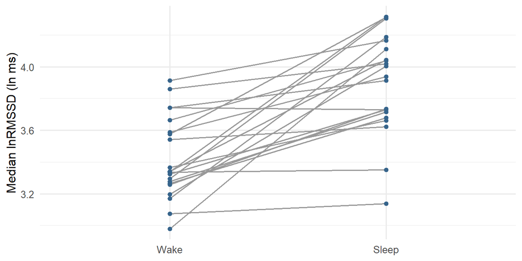

Figure 1: Per-participant median lnRMSSD during wakefulness and sleep.

## 24-h profile

The clock-time smooth explained substantial variation in lnRMSSD (edf = 9.7; adjusted R² including participant effects = 0.31). lnRMSSD rose through the night, peaked in the early morning, dropped steeply around getting up, and stayed low and fairly flat during the day before rising again in the late evening (Figure 2). Heart rate showed the mirror image. Allowing each participant their own curve improved fit (AIC 917 vs 1091).

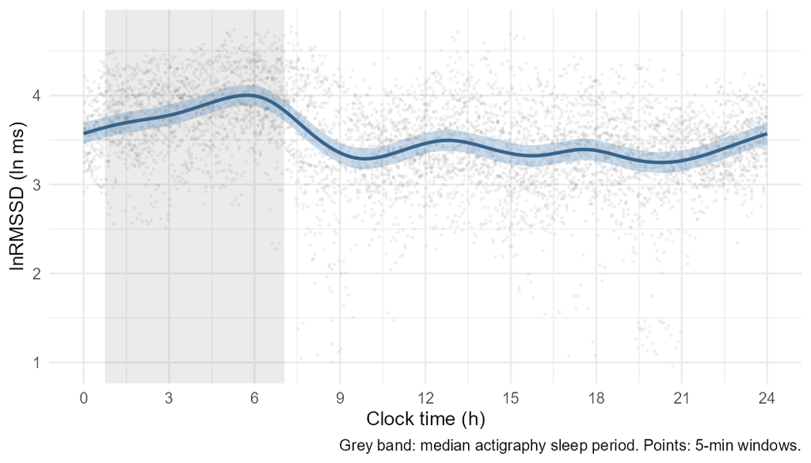

Figure 2: Estimated 24-h lnRMSSD profile (GAMM, 95 % CI) with 5-min windows.

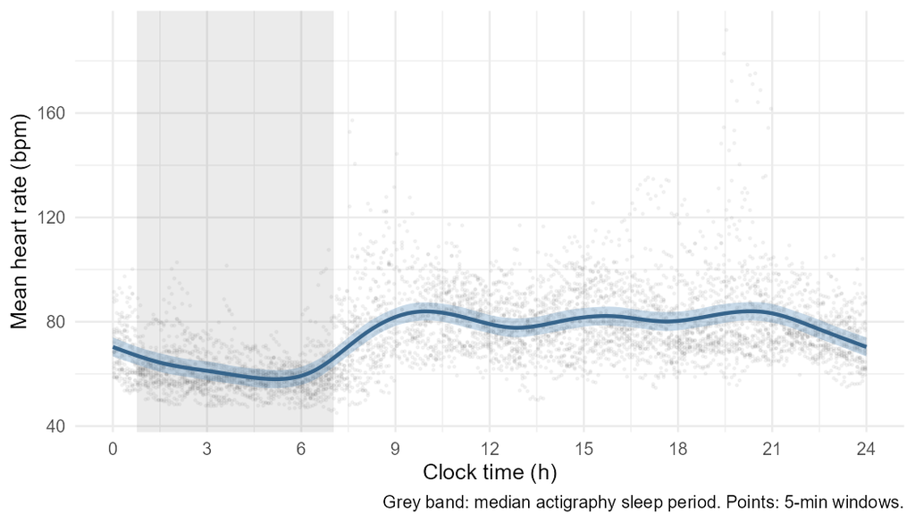

Figure 3: Estimated 24-h heart rate profile.

**Chronotype (exploratory).** The clock × MEQ interaction had a nominal p < 0.001 (edf 3.4). However, MEQ varies only between the 22 participants, the MEQ range was narrow (few clear morning types), and the predicted curves overlap almost entirely (Figure 4). An earlier random-intercept-only version gave a far smaller p-value, which shows how sensitive this test is to the random-effect structure. I do not interpret it as evidence of a chronotype effect.

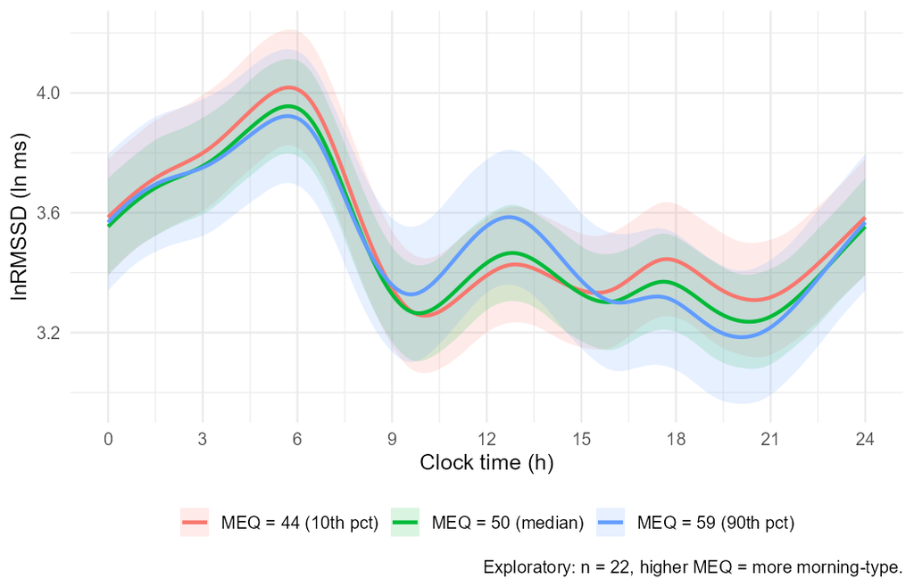

Figure 4: Predicted lnRMSSD profiles at the 10th, 50th and 90th percentile of MEQ.

## HRV before PANAS ratings

Using 92 ratings from 21 participants, within-person deviations in lnRMSSD in the preceding hour were not associated with positive affect (b = -1.17, p = 0.395) or negative affect (b = 0.09, p = 0.934). With at most five ratings per person, the design has little power. This is an inconclusive null result, not evidence of no coupling.

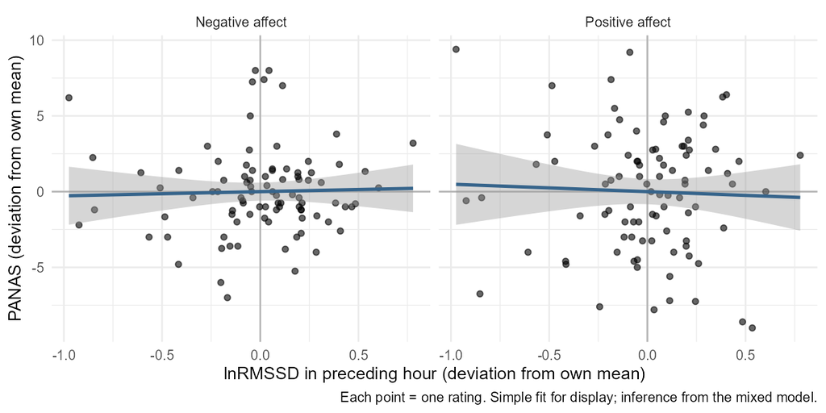

Figure 5: Within-person deviations of lnRMSSD (preceding hour) and PANAS scores.

# Limitations

n = 22, men only, aged 20–40 (age missing for one), one 24-h recording each. Clock time is not circadian phase: there is no DLMO or core body temperature, and the profile mixes endogenous rhythm with behaviour (sleep, posture, activity, meals). Sleep periods are estimated from actigraphy, not polysomnography, so sleep stages are unknown. IBIs are device-derived by the Polar H7, not measured from raw ECG, and about a quarter of each recording is missing in regular gaps. Wake windows include physical activity, which was not modelled. GAMM p-values are approximate, and between-person effects rest on 22 people. All analyses are exploratory and do not support causal claims.

# References

Balter, Leonie J. T., Benjamin C. Holding, Predrag Petrovic, and John Axelsson. 2024. “The Rhythm of Mental Health: The Relationship of Chronotype with Psychiatric Trait Dimensions and Diurnal Variation in Psychiatric Symptoms.” *Translational Psychiatry* 14: 237. https://doi.org/10.1038/s41398-024-02943-7.

Laborde, Sylvain, Emma Mosley, and Julian F. Thayer. 2017. “Heart Rate Variability and Cardiac Vagal Tone in Psychophysiological Research – Recommendations for Experiment Planning, Data Analysis, and Data Reporting.” *Frontiers in Psychology* 8: 213. https://doi.org/10.3389/fpsyg.2017.00213.

Rossi, Alessio, Eleonora Da Pozzo, Dario Menicagli, et al. 2020a. “A Public Dataset of 24-h Multi-Levels Psycho-Physiological Responses in Young Healthy Adults.” *Data* 5 (4): 91. https://doi.org/10.3390/data5040091.

Rossi, Alessio, Eleonora Da Pozzo, Dario Menicagli, et al. 2020b. *Multilevel Monitoring of Activity and Sleep in Healthy People (Version 1.0.0)*. PhysioNet. https://doi.org/10.13026/cerq-fc86.

Shaffer, Fred, and J. P. Ginsberg. 2017. “An Overview of Heart Rate Variability Metrics and Norms.” *Frontiers in Public Health* 5: 258. https://doi.org/10.3389/fpubh.2017.00258.